# Ft Riley avian point transects

Ft Riley 2020 avian survey using covariates for bout-specific estimates. Minor revision to treat `bout` explicitly as stratum.

Rexstad (CREEM, University of St Andrews)https://www.creem.st-andrews.ac.uk/  
2021-11-03

Load the packages to be used

```r
library(Distance)
library(readxl)
library(knitr)
library(kableExtra)
```

Acquire data from the spreadsheet. Note how `na=` argument is used.

```r
spreadsheet.file <- "BBS_Observations_Master.xlsx"
birds <- as.data.frame(read_xlsx(path=spreadsheet.file, sheet="Observaitons", na="NA"))
```

Make adjustments to column names to conform to convention used in the `Distance` package.

```r
names(birds)[7] <- "obsname"
birds$Effort <- birds$effort
birds$Region.Label <- birds$bout  # explicitly make bouts into Strata
birds$Sample.Label <- birds$pid
birds$Area <- 1
```

Specify units of measure. With point transects there are no distances associated with `Effort`, that argument is set to `NULL`.

```r
birdunits <- convert_units("meter", NULL, "square kilometer")
```

There are also a couple of functions I will define here to be used later in our analysis.

```r
cvmtest <- function(dsobject) {
#  Small function that prints Cramer-von Mises test and associated P-value
  cvmw <- round(gof_ds(dsobject, plot=FALSE)$dsgof$CvM$W, 3)
  cvmp <- round(gof_ds(dsobject, plot=FALSE)$dsgof$CvM$p, 3)
  print(paste("CvM W=", cvmw, "P=", cvmp))
}

visitplot <- function(dsobject) {
# plots visit-specific detection functions
  plot(dsobject, pdf=TRUE, showpoints=FALSE, main="Detection function with visit as covariate")
  add_df_covar_line(dsobject, data=data.frame(Region.Label=as.factor(1)),
                    pdf=TRUE, lty=1, col="blue")
  add_df_covar_line(dsobject, data=data.frame(Region.Label=as.factor(2)),
                    pdf=TRUE, lty=1, col="green")
  add_df_covar_line(dsobject, data=data.frame(Region.Label=as.factor(3)),
                    pdf=TRUE, lty=1, col="red")
  legend("topright", lty=1, legend=c("Visit 1", "Visit 2", "Visit 3"),
         col=c("blue", "green", "red"))
}
```

# Northern bobwhite

## Treating visit as stratum

```r
birds$Effort <- 1
mytruncation <- "10%"
nobo <- birds[(birds$species=="NOBO")  | is.na(birds$distance), ]
nobo.vstrat <- ds(data=nobo,
                transect="point", key="hr", formula=~as.factor(Region.Label),
                truncation = mytruncation, convert.units = birdunits)
nobo.ests <- dht2(ddf=nobo.vstrat, flatfile=nobo,
                  strat_formula = ~as.factor(Region.Label), convert_units = birdunits,
                  stratification = "replicate")
print(nobo.ests, report="density")
```

```
Density estimates from distance sampling
Stratification : replicate
Variance       : P2, n/L
Multipliers    : none
Sample fraction : 1


Summary statistics:
 as.factor(Region.Label) Area CoveredArea Effort   n   k    ER se.ER
                       1    1    50.76814    101  67 101 0.663 0.088
                       2    1    50.26548    100 157 100 1.570 0.153
                       3    1    49.76283     99  97  99 0.980 0.112
                   Total    1   150.79645    300 321 300 1.070 0.070
 cv.ER
 0.133
 0.097
 0.114
 0.065

Density estimates:
 as.factor(Region.Label) Estimate    se    cv    LCI    UCI      df
                       1   2.5127 0.464 0.185 1.7520 3.6039 292.991
                       2   3.9766 0.468 0.118 3.1549 5.0123 199.848
                       3   2.5003 0.353 0.141 1.8949 3.2991 210.107
                   Total   2.9966 0.516 0.172 1.6146 5.5613   2.459

Component percentages of variance:
 as.factor(Region.Label) Detection    ER
                       1     14.33 85.67
                       2     23.84 76.16
                       3     18.42 81.58
                   Total     41.17 58.83
```

```r
cvmtest(nobo.vstrat)
```

```
[1] "CvM W= 0.178 P= 0.315"
```

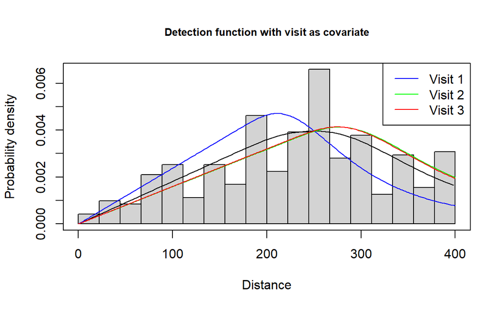

Figure 1: Northern bobwhite detection function with visit as a covariate

```r
visitplot(nobo.vstrat)
```

# Dickcissel

## Treating visit as stratum

Assuming detection functions for each visit share a common key function.

```r
dick <- birds[(birds$species=="DICK")  | is.na(birds$distance), ]
dick.vstrat <- ds(data=dick,
                transect="point", key="hr", formula=~as.factor(Region.Label),
                truncation = mytruncation, convert.units = birdunits)
dick.ests <- dht2(ddf=dick.vstrat, flatfile=dick,
                  strat_formula = ~as.factor(Region.Label), convert_units = birdunits,
                  stratification = "replicate")
print(dick.ests, report="density")
```

```
Density estimates from distance sampling
Stratification : replicate
Variance       : P2, n/L
Multipliers    : none
Sample fraction : 1


Summary statistics:
 as.factor(Region.Label) Area CoveredArea Effort   n   k    ER se.ER
                       1    1    7.139269    101 245 101 2.426 0.185
                       2    1    7.068583    100 289 100 2.890 0.207
                       3    1    6.997898     99 219  99 2.212 0.187
                   Total    1   21.205750    300 753 300 2.510 0.112
 cv.ER
 0.076
 0.072
 0.084
 0.044

Density estimates:
 as.factor(Region.Label) Estimate     se    cv      LCI      UCI
                       1  85.3154  9.316 0.109  68.8735 105.6824
                       2 126.8065 13.280 0.105 103.2676 155.7110
                       3  74.9527  8.935 0.119  59.3361  94.6794
                   Total  95.7261 16.522 0.173  50.6829 180.8002
      df
 364.650
 386.869
 344.734
   2.376

Component percentages of variance:
 as.factor(Region.Label) Detection    ER
                       1     29.77 70.23
                       2     32.54 67.46
                       3     25.75 74.25
                   Total     55.59 44.41
```

```r
cvmtest(dick.vstrat)
```

```
[1] "CvM W= 0.199 P= 0.269"
```

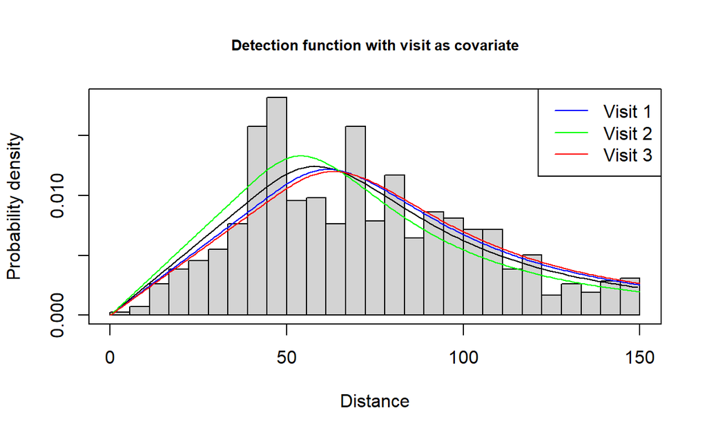

Figure 2: Dickcissel detection function with visit as a covariate

```r
visitplot(dick.vstrat)
```

# Brown headed cowbird

## Visit as stratum covariate

Adjust effort for per-visit analysis

```r
bhco <- birds[(birds$species=="BHCO")  | is.na(birds$distance), ]
bhco.vstrat <- ds(data=bhco,
                transect="point", key="hr", formula=~as.factor(Region.Label),
                truncation = mytruncation, convert.units = birdunits)
bhco.ests <- dht2(ddf=bhco.vstrat, flatfile=bhco,
                  strat_formula = ~as.factor(Region.Label), convert_units = birdunits,
                  stratification = "replicate")
print(bhco.ests, report="density")
```

```
Density estimates from distance sampling
Stratification : replicate
Variance       : P2, n/L
Multipliers    : none
Sample fraction : 1


Summary statistics:
 as.factor(Region.Label) Area CoveredArea Effort   n   k    ER se.ER
                       1    1    12.99847    101 125 101 1.238 0.152
                       2    1    12.86977    100 136 100 1.360 0.209
                       3    1    12.74108     99  49  99 0.495 0.118
                   Total    1    38.60932    300 310 300 1.033 0.095
 cv.ER
 0.123
 0.154
 0.238
 0.092

Density estimates:
 as.factor(Region.Label) Estimate     se    cv     LCI      UCI
                       1  49.3019  9.513 0.193 33.8503  71.8067
                       2  44.6948  9.198 0.206 29.9290  66.7454
                       3  12.0183  3.899 0.324  6.4476  22.4022
                   Total  35.4626 12.246 0.345 10.2662 122.4985
      df
 358.424
 264.096
 273.446
   2.392

Component percentages of variance:
 as.factor(Region.Label) Detection    ER
                       1     40.60 59.40
                       2     30.26 69.74
                       3     15.33 84.67
                   Total     54.96 45.04
```

```r
cvmtest(bhco.vstrat)
```

```
[1] "CvM W= 0.123 P= 0.482"
```

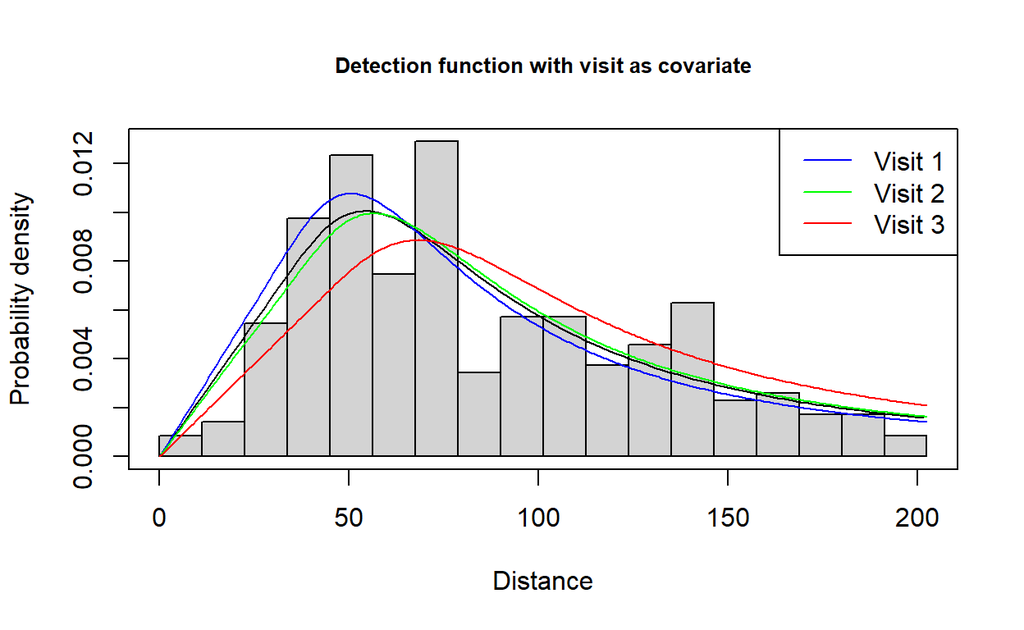

Figure 3: Brown headed cowbird detection function with visit as a covariate

```r
visitplot(bhco.vstrat)
```

# Eastern meadowlark

## Visit as stratum covariate

Adjust effort for per-visit analysis

```r
eame <- birds[(birds$species=="EAME")  | is.na(birds$distance), ]
eame.vstrat <- ds(data=eame,
                transect="point", key="hr", formula=~as.factor(Region.Label),
                truncation = mytruncation, convert.units = birdunits)
eame.ests <- dht2(ddf=eame.vstrat, flatfile=eame,
                  strat_formula = ~as.factor(Region.Label), convert_units = birdunits,
                  stratification = "replicate")
print(eame.ests, report="density")
```

```
Density estimates from distance sampling
Stratification : replicate
Variance       : P2, n/L
Multipliers    : none
Sample fraction : 1


Summary statistics:
 as.factor(Region.Label) Area CoveredArea Effort   n   k    ER se.ER
                       1    1    13.87329    101 100 101 0.990 0.126
                       2    1    13.73593    100  86 100 0.860 0.113
                       3    1    13.59857     99  84  99 0.848 0.121
                   Total    1    41.20778    300 270 300 0.900 0.069
 cv.ER
 0.128
 0.131
 0.143
 0.077

Density estimates:
 as.factor(Region.Label) Estimate    se    cv    LCI     UCI      df
                       1  11.9506 2.168 0.181 8.3863 17.0298 293.884
                       2  12.8943 2.756 0.214 8.5087 19.5404 345.512
                       3  11.7522 2.482 0.211 7.7910 17.7274 308.150
                   Total  12.1997 1.256 0.103 9.9601 14.9430 159.380

Component percentages of variance:
 as.factor(Region.Label) Detection    ER
                       1     37.57 62.43
                       2     36.24 63.76
                       3     32.38 67.62
                   Total     62.17 37.83
```

```r
cvmtest(eame.vstrat)
```

```
[1] "CvM W= 0.104 P= 0.567"
```

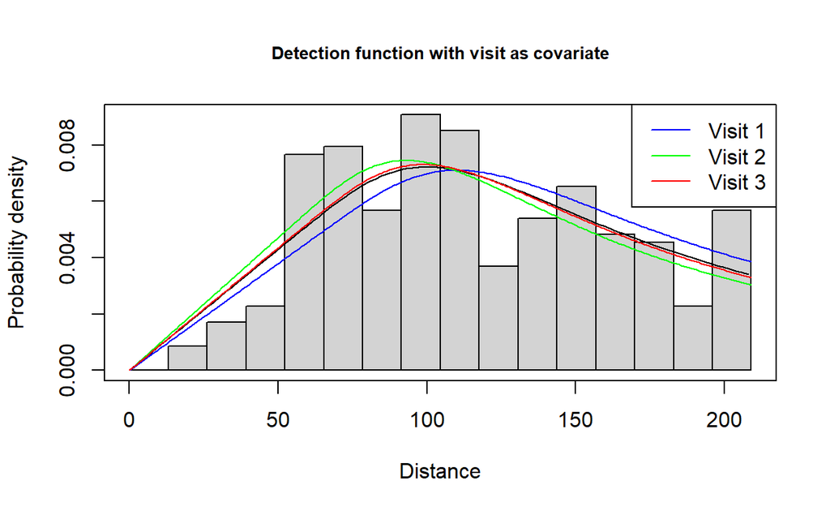

Figure 4: Eastern meadowlark detection function with visit as a covariate

```r
visitplot(eame.vstrat)
```

# Bell’s vireo

## Visit as stratum covariate

Adjust effort for per-visit analysis

```r
bevi <- birds[(birds$species=="BEVI")  | is.na(birds$distance), ]
bevi.vstrat <- ds(data=bevi,
                transect="point", key="hr", formula=~as.factor(Region.Label),
                truncation = mytruncation, convert.units = birdunits)
bevi.ests <- dht2(ddf=bevi.vstrat, flatfile=bevi,
                  strat_formula = ~as.factor(Region.Label), convert_units = birdunits,
                  stratification = "replicate")
print(bevi.ests, report="density")
```

```
Density estimates from distance sampling
Stratification : replicate
Variance       : P2, n/L
Multipliers    : none
Sample fraction : 1


Summary statistics:
 as.factor(Region.Label) Area CoveredArea Effort   n   k    ER se.ER
                       1    1    5.595867    101 100 101 0.990 0.123
                       2    1    5.540463    100  48 100 0.480 0.066
                       3    1    5.485058     99  40  99 0.404 0.067
                   Total    1   16.621388    300 188 300 0.627 0.052
 cv.ER
 0.124
 0.137
 0.166
 0.083

Density estimates:
 as.factor(Region.Label) Estimate     se    cv     LCI     UCI
                       1  51.0833 11.652 0.228 32.7904 79.5812
                       2  34.4843 11.753 0.341 17.9488 66.2534
                       3  28.5663 11.344 0.397 13.4441 60.6984
                   Total  38.1197  9.519 0.250 21.5730 67.3578
      df
 280.267
 245.045
 249.450
   7.830

Component percentages of variance:
 as.factor(Region.Label) Detection    ER
                       1     66.81 33.19
                       2     62.28 37.72
                       3     52.91 47.09
                   Total     81.95 18.05
```

```r
cvmtest(bevi.vstrat)
```

```
[1] "CvM W= 0.059 P= 0.823"
```

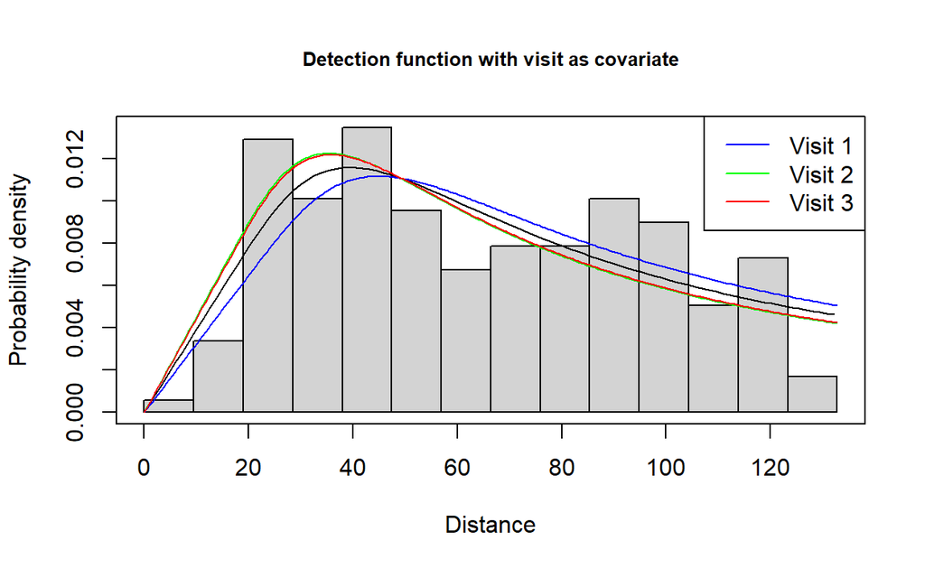

Figure 5: Bells vireo detection function with visit as a covariate

```r
visitplot(bevi.vstrat)
```

# Henslow’s sparrow

## Visit as stratum covariate

Adjust effort for per-visit analysis

```r
hesp <- birds[(birds$species=="HESP")  | is.na(birds$distance), ]
hesp.vstrat <- ds(data=hesp,
                transect="point", key="hn", formula=~as.factor(Region.Label),
                truncation = mytruncation, convert.units = birdunits)
hesp.ests <- dht2(ddf=hesp.vstrat, flatfile=hesp,
                  strat_formula = ~as.factor(Region.Label), convert_units = birdunits,
                  stratification = "replicate")
print(hesp.ests, report="density")
```

```
Density estimates from distance sampling
Stratification : replicate
Variance       : P2, n/L
Multipliers    : none
Sample fraction : 1


Summary statistics:
 as.factor(Region.Label) Area CoveredArea Effort  n   k    ER se.ER
                       1    1    2.335855    101  8 101 0.079 0.034
                       2    1    2.312727    100 15 100 0.150 0.050
                       3    1    2.289600     99 17  99 0.172 0.052
                   Total    1    6.938182    300 40 300 0.133 0.026
 cv.ER
 0.424
 0.333
 0.302
 0.198

Density estimates:
 as.factor(Region.Label) Estimate     se    cv    LCI     UCI     df
                       1  13.7091 14.445 1.054 2.4203 77.6494 51.921
                       2   8.2046  4.373 0.533 3.0368 22.1667 86.482
                       3   9.5639  5.437 0.569 3.3264 27.4974 67.828
                   Total  10.5063  5.117 0.487 4.1249 26.7603 36.795

Component percentages of variance:
 as.factor(Region.Label) Detection    ER
                       1     54.86 45.14
                       2     66.24 33.76
                       3     70.51 29.49
                   Total     84.74 15.26
```

```r
cvmtest(hesp.vstrat)
```

```
[1] "CvM W= 0.14 P= 0.423"
```

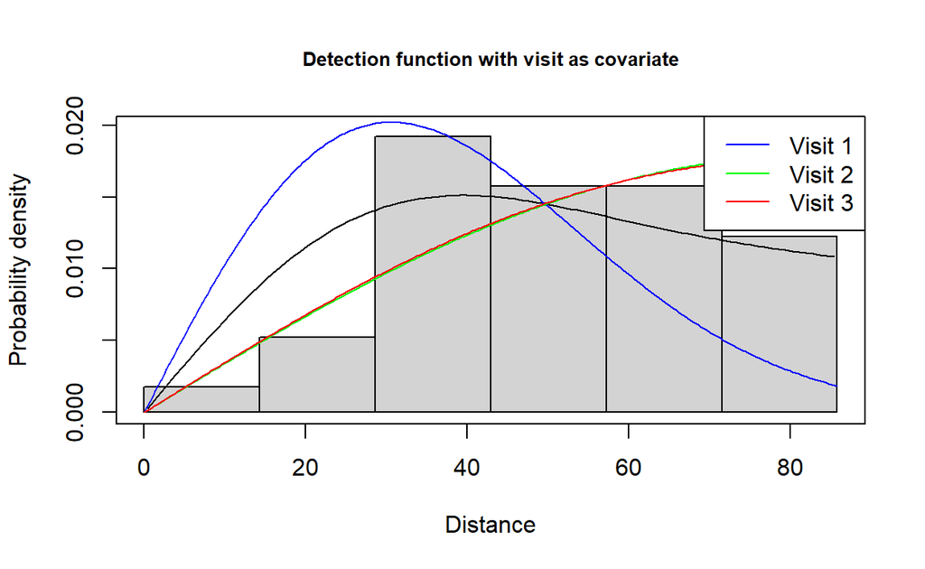

Figure 6: Henslows sparrow detection function with visit as a covariate

```r
visitplot(hesp.vstrat)
```

The plot of bout-specific detection functions makes the estimation enterprise dubious.

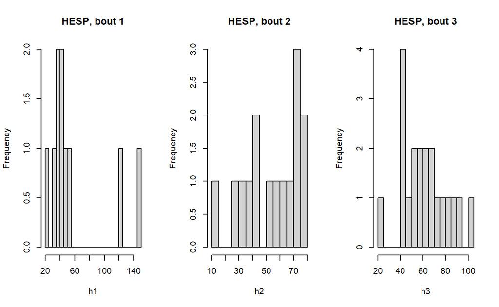

```r
hesp <- birds[(birds$species=="HESP"), ]
h1 <- hesp[hesp$bout == 1, "distance"]
h2 <- hesp[hesp$bout == 2, "distance"]
h3 <- hesp[hesp$bout == 3, "distance"]
par(mfrow=c(1,3))
hist(h1, main="HESP, bout 1", nc=20)
hist(h2, main="HESP, bout 2", nc=20)
hist(h3, main="HESP, bout 3", nc=20)
```

```r
par(mfrow=c(1,1))
```

# Addendum

What are the consequences of employing covariates in the detection function (beyond covariate for sampling session)? Many other covariates were collected at the time of data collection, presumably because of their potential explanatory power in detection function modelling. I will demonstrate the effect of a couple of covariates on the detection function of dickcissel.

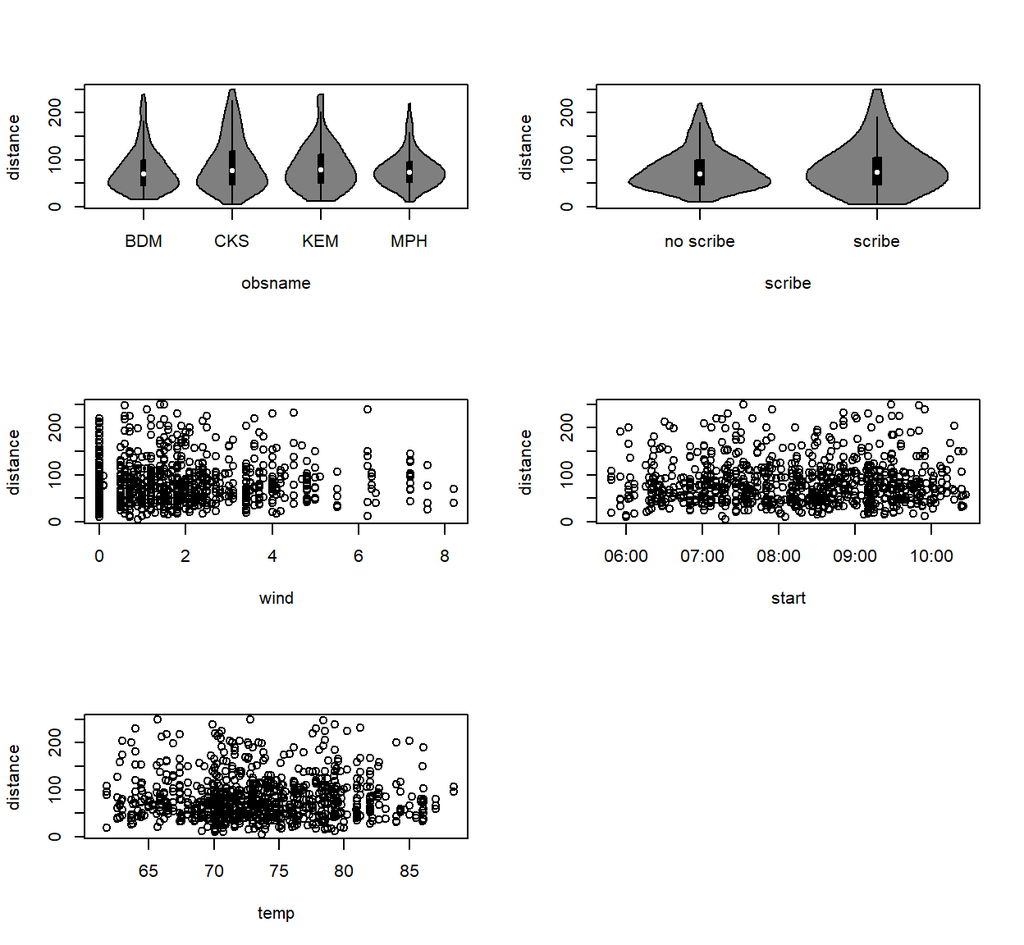

Figure 7: Exploratory data analysis of dickcissel detection function covariates.

Nothing is evident in the exploratory plots; I suspect nothing will arise from covariate modelling. To demonstrate the point, a barrage of single covariate models with above covariates (and hazard rate key), compared with pooled hazard rate without covariates:

Table 1: Model selection for covariate models with Dickcissel 2020

| Key function | Formula | C-vM p-value | $\hat{P_a}$ | se($\hat{P_a}$) | $\Delta$AIC |
| --- | --- | --- | --- | --- | --- |
| Hazard-rate | ~scale(wind) | 0.27 | 0.37722 | 0.02 | 0.00000 |
| Hazard-rate | ~obsname | 0.19 | 0.37061 | 0.02 | 1.84462 |
| Hazard-rate | ~1 | 0.20 | 0.37986 | 0.02 | 3.29081 |
| Hazard-rate | ~scribe | 0.23 | 0.38090 | 0.02 | 4.61178 |
| Hazard-rate | ~scale(start) | 0.21 | 0.37952 | 0.02 | 4.97668 |
| Hazard-rate | ~scale(temp) | 0.20 | 0.37995 | 0.02 | 5.24620 |

Look not only at the $\Delta$AIC but also at the differences in $\hat{P_a}$. These differences translate into differences in $\hat{D}$

Table 2: Density estimates for Dickcissel from various covariate models

|  | Estimate | se | cv | lcl | ucl |
| --- | --- | --- | --- | --- | --- |
| Observer | 96.536 | 6.458 | 0.067 | 84.672 | 110.063 |
| Scribe | 93.954 | 6.176 | 0.066 | 82.593 | 106.879 |
| Wind | 94.870 | 6.258 | 0.066 | 83.361 | 107.968 |
| Start | 94.291 | 6.199 | 0.066 | 82.888 | 107.262 |
| Temp | 94.174 | 6.187 | 0.066 | 82.792 | 107.120 |
| Nothing | 94.197 | 6.196 | 0.066 | 82.801 | 107.161 |